# Distribuciones de Probabilidad y Pruebas de Hipótesis

Isaac Zainea

2024-09-20

# Introducción

En este documento vamos a explorar las **distribuciones de probabilidad** más comunes y una introducción a las **pruebas de hipótesis** usando R.

## 1. Distribuciones de Probabilidad

### 1.1 Distribución Binomial

La distribución binomial modela el número de éxitos en una secuencia de ensayos independientes y con la misma probabilidad de éxito. La fórmula es:

$$P(X = k) = \binom{n}{k} p^k (1-p)^{n-k}$$

En R podemos simular datos de una distribución binomial:

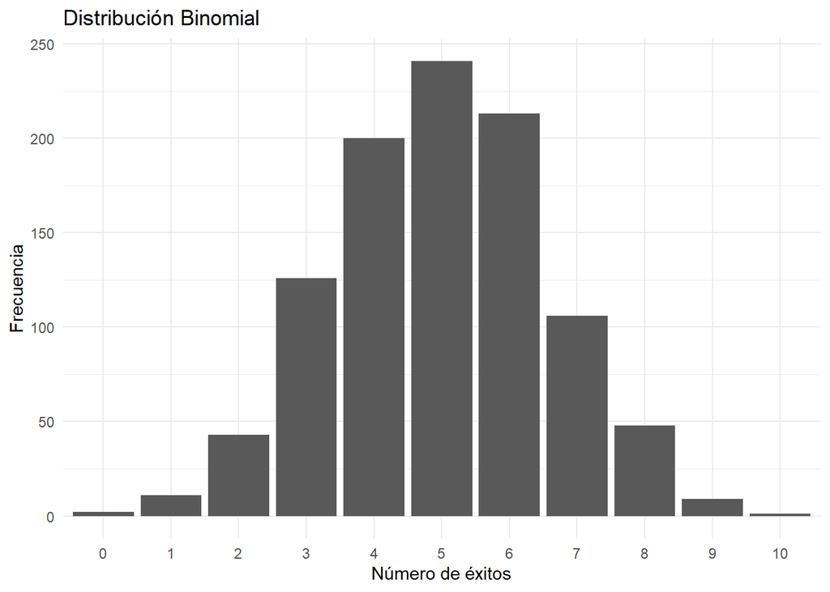

```r
# Simulación de una distribución binomial
n <- 10  # número de ensayos
p <- 0.5 # probabilidad de éxito

set.seed(123)
binomial_data <- rbinom(1000, size = n, prob = p)

# Graficar la distribución
library(ggplot2)
ggplot(data.frame(x = binomial_data), aes(x = factor(x))) +
  geom_bar() +
  labs(title = "Distribución Binomial", x = "Número de éxitos", y = "Frecuencia") +
  theme_minimal()
```

### 1.2 Distribución Normal

La distribución normal es una de las más importantes en estadística. Su función de densidad está definida por la media y la desviación estándar:

$$f(x) = \frac{1}{\sqrt{2\pi\sigma^2}} e^{-\frac{(x-\mu)^2}{2\sigma^2}}$$

Podemos simular datos de una distribución normal con `rnorm()`:

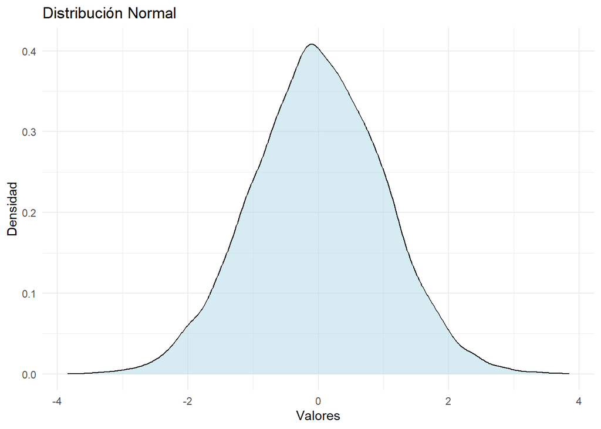

```r
# Simulación de una distribución normal
mu <- 0   # media
sigma <- 1 # desviación estándar

normal_data <- rnorm(10000, mean = mu, sd = sigma)

# Graficar la distribución
ggplot(data.frame(x = normal_data), aes(x = x)) +
  geom_density(fill = "lightblue", alpha = 0.5) +
  labs(title = "Distribución Normal", x = "Valores", y = "Densidad") +
  theme_minimal()
```

### 1.3 Distribución t-Student

La distribución t-Student se usa cuando el tamaño de la muestra es pequeño o no se conoce la desviación estándar poblacional.

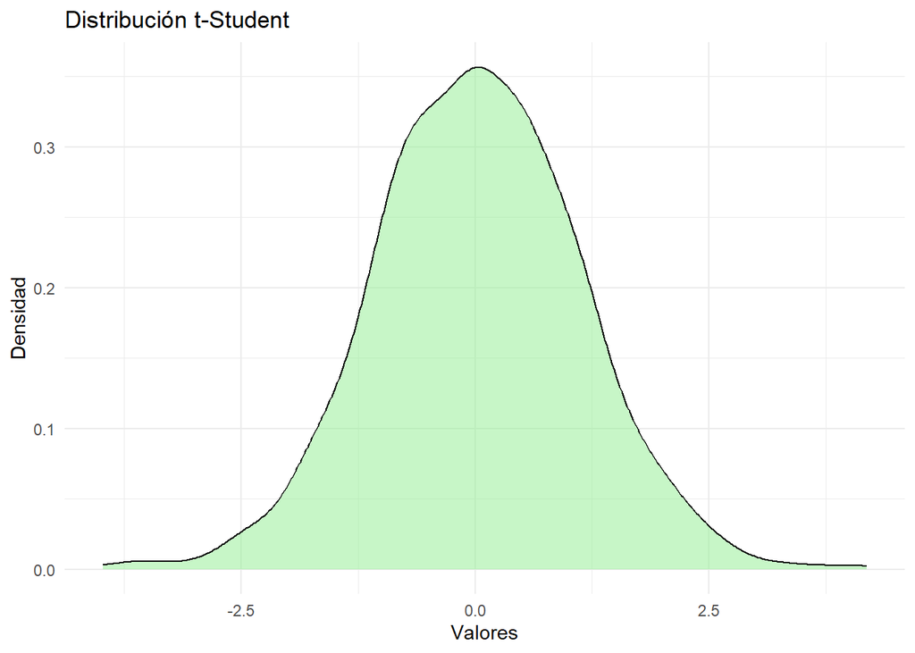

```r
# Simulación de una distribución t
t_data <- rt(1000, df = 10)

# Graficar la distribución
ggplot(data.frame(x = t_data), aes(x = x)) +
  geom_density(fill = "lightgreen", alpha = 0.5) +
  labs(title = "Distribución t-Student", x = "Valores", y = "Densidad") +
  theme_minimal()
```

## 2. Pruebas de Hipótesis

### 2.1 Conceptos Clave

Una prueba de hipótesis nos permite tomar decisiones sobre una población basándonos en una muestra. Definimos dos hipótesis: - Hipótesis nula ($H_0$): no hay diferencia. - Hipótesis alternativa ($H_1$): sí hay diferencia.

### 2.2 Prueba t de una muestra

Queremos probar si la media de una muestra es diferente de un valor hipotético. Usamos la prueba t de una muestra.

```r
# Datos simulados
set.seed(123)
sample_data <- rnorm(30, mean = 5, sd = 1)

# Prueba t de una muestra
t_test <- t.test(sample_data, mu = 5)
t_test
```

```
##
##  One Sample t-test
##
## data:  sample_data
## t = -0.26299, df = 29, p-value = 0.7944
## alternative hypothesis: true mean is not equal to 5
## 95 percent confidence interval:
##  4.586573 5.319219
## sample estimates:
## mean of x
##  4.952896
```

### 2.3 Visualización de la Prueba t

Podemos visualizar la distribución de la prueba t y la región de rechazo:

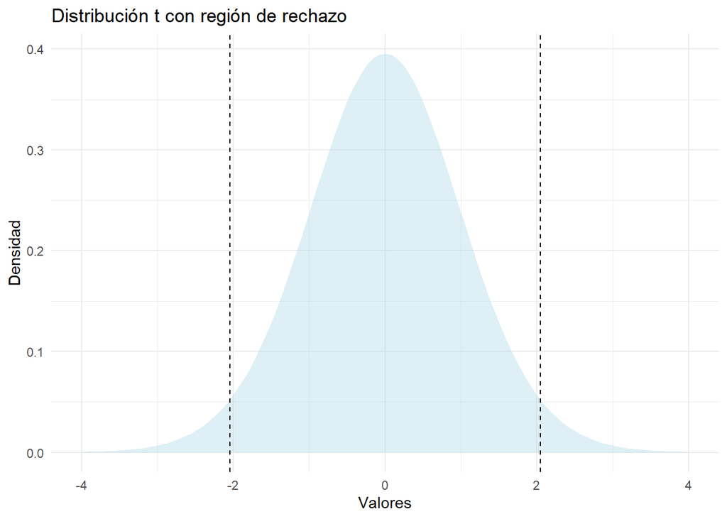

```r
# Gráfico de la distribución t con la región de rechazo
ggplot(data.frame(x = c(-4, 4)), aes(x = x)) +
  stat_function(fun = dt, args = list(df = 29), geom = "area", fill = "lightblue", alpha = 0.4) +
  geom_vline(xintercept = c(-qt(0.975, df = 29), qt(0.975, df = 29)), linetype = "dashed") +
  labs(title = "Distribución t con región de rechazo", x = "Valores", y = "Densidad") +
  theme_minimal()
```

La hipótesis nula es (usualmente):

$$H_0: \mu = v \text{\ \ \ No hay diferencia entre \mu y $v$}$$

$$H_1: \mu \neq v \text{\ \ \ Hay diferencia entre \mu y $v$}$$

1. Si $p<0.05$ se rechaza la hipótesis nula, luego hay evidencia para afirmar que se cumple la hipótesis alternativa.
2. Si $p>=0.05$ no puedo rechazar la hipótesis nula. No hay evidencia suficiente para afirmar que la media es diferente al valor $v$.

### 2.4 Prueba t para dos muestras

Ahora probamos si dos muestras tienen medias significativamente diferentes.

```r
# Datos simulados
set.seed(123)
group1 <- rnorm(30, mean = 5, sd = 1)
group2 <- rnorm(30, mean = 6, sd = 1)

# Prueba t para dos muestras independientes
t_test_2 <- t.test(group1, group2)
t_test_2
```

```
##
##  Welch Two Sample t-test
##
## data:  group1 and group2
## t = -5.2098, df = 56.559, p-value = 2.755e-06
## alternative hypothesis: true difference in means is not equal to 0
## 95 percent confidence interval:
##  -1.6965426 -0.7543416
## sample estimates:
## mean of x mean of y
##  4.952896  6.178338
```

## Conclusión

Hemos cubierto las distribuciones de probabilidad más comunes y cómo realizar pruebas de hipótesis básicas en R. Estas herramientas son fundamentales para el análisis estadístico y nos permiten hacer inferencias a partir de muestras.